# BOLT 🚀 Case Study for "Senior Data Scientist"

## *by: Ashish Kumar, e-mail: ds.ashish@hotmail.com*

#### *Solution: The main expectation of the case study is to find out the high demand locations with respect to time based on the historical data. For this we need to forecast the demand of rides based on locations and time.* (See conclusion of the case study at the end of the Notebook)

## High Level Architecture of solution of the rider-drivers case study

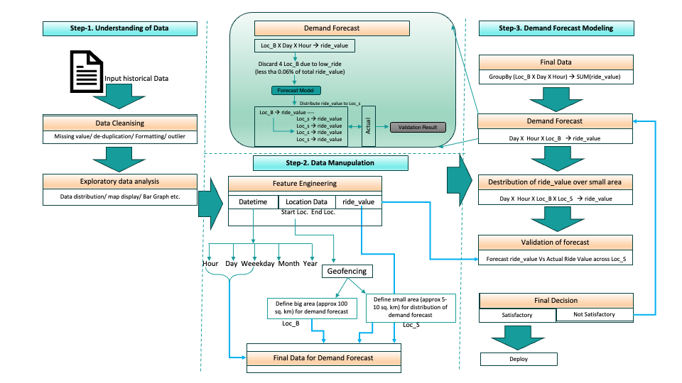

```python
from IPython.display import Image
Image("architecture.png")
```

### Case study steps:

1. Data processing and Cleansing (Null value treatment, de-duplication etc.)
2. Understanding of Data and EDA (Exploratory data analysis)
3. Data pre-processing:

   i) Transformation of Datetime stamp to Day, Weekday, Month and Year for analysis and forecast

   *Note: square grid boxes have been used for this case study but polygon geofencing would be better because it covers the high density area and discards the non-active area on the map.*

   *Note: The grid boxes (Loc_B) that have less than 1% ride_value have been removed from the analysis as they cover the low demand area.*
4. Demand Forecasting:

   i) Generate Demand Forecast across 10 grid big boxes(Loc_B) [Remove the grid boxes has less than 1% ride_value]. ARIMA and ETS have been used for generation of demand forecast.

   ii) Distribution of demand forecast over 100 small grid box (Loc_S) on the basis of their last week contribution.

   iii) Accuracy calculation of ARIMA and ETS iv) Generation of demand forecast using XGBoost Regressor for better result and comparison of accuracy with ARIMA and ETS.

   *Note: Daily level data has been used to generate demand forecast (as the data frequency is not mentioned in the task). In case of actual deployment at hourly level, the daily level data can be distributed on an hourly basis based on every weekday of the week.*

```python
import pandas as pd
import matplotlib.pyplot as plt
import geopandas as gpd
import numpy as np
from shapely.geometry import Point, LineString
from geopy.distance import geodesic

from statsmodels.tsa.holtwinters import ExponentialSmoothing
from statsmodels.tsa.arima.model import ARIMA
from sklearn.metrics import mean_absolute_error, mean_squared_error
import seaborn as sns
import xgboost as xgb
from sklearn.model_selection import GridSearchCV, train_test_split
from scipy.stats import gaussian_kde

print('Libraries imported')
```

```python
# data import
df = pd.read_csv('robotex5.csv')
```

```python
df.dtypes
```

```
start_time     object
start_lat     float64
start_lng     float64
end_lat       float64
end_lng       float64
ride_value    float64
dtype: object
```

# 1. Data Cleansing

```python
df.isna().sum()
```

```
start_time    0
start_lat     0
start_lng     0
end_lat       0
end_lng       0
ride_value    0
dtype: int64
```

```python
df.duplicated().sum()
```

```
4564
```

```python
df.drop_duplicates(inplace=True)
```

## Feature Engineering

```python
# convert the 'datetime' column to pandas datetime
df['time_pickup'] = pd.to_datetime(df['start_time'], utc=True)

# extract the components
df['weekday'] = df['time_pickup'].dt.weekday
df['day'] = df['time_pickup'].dt.day
df['month'] = df['time_pickup'].dt.month
df['year'] = df['time_pickup'].dt.year
df['hour'] = df['time_pickup'].dt.hour
# df.head()
```

```python
df.head()
```

|  | start_time | start_lat | start_lng | end_lat | end_lng | ride_value | time_pickup | weekday | day | month | year | hour |
| --- | --- | --- | --- | --- | --- | --- | --- | --- | --- | --- | --- | --- |
| 0 | 2022-03-06 15:02:39.329452000 | 59.407910 | 24.689836 | 59.513027 | 24.831630 | 3.51825 | 2022-03-06 15:02:39.329452+00:00 | 6 | 6 | 3 | 2022 | 15 |
| 1 | 2022-03-10 11:15:55.177526000 | 59.441650 | 24.762712 | 59.426450 | 24.783076 | 0.50750 | 2022-03-10 11:15:55.177526+00:00 | 3 | 10 | 3 | 2022 | 11 |
| 2 | 2022-03-06 14:23:33.893257000 | 59.435404 | 24.749795 | 59.431901 | 24.761588 | 0.19025 | 2022-03-06 14:23:33.893257+00:00 | 6 | 6 | 3 | 2022 | 14 |
| 3 | 2022-03-03 09:11:59.104192000 | 59.406920 | 24.659006 | 59.381093 | 24.641652 | 0.75600 | 2022-03-03 09:11:59.104192+00:00 | 3 | 3 | 3 | 2022 | 9 |
| 4 | 2022-03-06 00:13:01.290346000 | 59.434940 | 24.753641 | 59.489203 | 24.876170 | 2.27100 | 2022-03-06 00:13:01.290346+00:00 | 6 | 6 | 3 | 2022 | 0 |

```python
df = df[["start_time", "time_pickup", "year", "month", "weekday", "day", "hour",
          "start_lat", "start_lng", "end_lat", "end_lng", "ride_value"]]
```

```python
# Extract minimum and maximum latitude and longitude
min_lat, min_lng = df["start_lat"].min(), df["start_lng"].min()
max_lat, max_lng = df["start_lat"].max(), df["start_lng"].max()

# Calculate approximate area covered using geodesic distance
width_km = geodesic((min_lat, min_lng), (min_lat, max_lng)).km
height_km = geodesic((min_lat, min_lng), (max_lat, min_lng)).km
area_sq_km = width_km * height_km

# Print the calculated area
print(f"Total Area Covered: {area_sq_km:.2f} sq. km")
```

```
Total Area Covered: 729.45 sq. km
```

#### *NOTE: The total area coverage for the rider is 729.45 sq.km., the best is to divide the area into 100 sub-areas for demand forecast distribution (~ approx 7-8 sq.km area is best for rider) and 10 sub-area (~ approx 70-75 sq.km.) for actual forecast.*

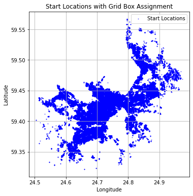

```python
# Creation of grid cell based on start location. (Loc_S)

## Create GeoDataFrame for start locations
df["start_geometry"] = df.apply(lambda row: Point(row["start_lng"], row["start_lat"]), axis=1)
gdf_start = gpd.GeoDataFrame(df, geometry="start_geometry")
gdf_start.set_crs(epsg=4326, inplace=True)

## Create a bounding box for the start locations
start_points = gdf_start.geometry.unary_union
min_lon, min_lat, max_lon, max_lat = start_points.bounds

## Define number of grid cells (1000 boxes)
num_boxes = 100

## Compute grid size based on bounding box dimensions
width_km = geodesic((min_lat, min_lon), (min_lat, max_lon)).km
height_km = geodesic((min_lat, min_lon), (max_lat, min_lon)).km
grid_width = width_km / np.sqrt(num_boxes)
grid_height = height_km / np.sqrt(num_boxes)

## Compute lat/lon step sizes
lat_step = (max_lat - min_lat) / np.sqrt(num_boxes)
lon_step = (max_lon - min_lon) / np.sqrt(num_boxes)

## Function to assign a grid cell ID to each start location
def assign_grid_cell(lat, lon):
    lat_index = int((lat - min_lat) / lat_step)
    lon_index = int((lon - min_lon) / lon_step)
    return lat_index * int(np.sqrt(num_boxes)) + lon_index

## Apply the function to assign grid cell IDs
df["grid_box_id"] = df.apply(lambda row: assign_grid_cell(row["start_lat"], row["start_lng"]), axis=1)

# Plot start locations with grid box IDs
fig, ax = plt.subplots(figsize=(10, 6))
gdf_start.plot(ax=ax, markersize=1, color='blue', alpha=0.5, label='Start Locations')
plt.xlabel("Longitude")
plt.ylabel("Latitude")
plt.title("Start Locations with Grid Box Assignment")
plt.legend()
plt.grid()
plt.show()
```

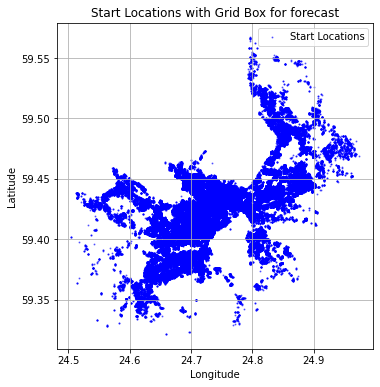

```python
# Creation of grid cell based on start location. (Loc_B)

## Create GeoDataFrame for start locations
df["start_geometry2"] = df.apply(lambda row: Point(row["start_lng"], row["start_lat"]), axis=1)
gdf_start = gpd.GeoDataFrame(df, geometry="start_geometry2")
gdf_start.set_crs(epsg=4326, inplace=True)

## Create a bounding box for the start locations
start_points = gdf_start.geometry.unary_union
min_lon, min_lat, max_lon, max_lat = start_points.bounds

## Define number of grid cells (1000 boxes)
num_boxes = 10

## Compute grid size based on bounding box dimensions
width_km = geodesic((min_lat, min_lon), (min_lat, max_lon)).km
height_km = geodesic((min_lat, min_lon), (max_lat, min_lon)).km
grid_width = width_km / np.sqrt(num_boxes)
grid_height = height_km / np.sqrt(num_boxes)

## Compute lat/lon step sizes
lat_step = (max_lat - min_lat) / np.sqrt(num_boxes)
lon_step = (max_lon - min_lon) / np.sqrt(num_boxes)

## Function to assign a grid cell ID to each start location
def assign_grid_cell(lat, lon):
    lat_index = int((lat - min_lat) / lat_step)
    lon_index = int((lon - min_lon) / lon_step)
    return lat_index * int(np.sqrt(num_boxes)) + lon_index

## Apply the function to assign grid cell IDs
df["grid_box_id2"] = df.apply(lambda row: assign_grid_cell(row["start_lat"], row["start_lng"]), axis=1)

# Plot start locations with grid box IDs
fig, ax = plt.subplots(figsize=(10, 6))
gdf_start.plot(ax=ax, markersize=1, color='blue', alpha=0.5, label='Start Locations')
plt.xlabel("Longitude")
plt.ylabel("Latitude")
plt.title("Start Locations with Grid Box for forecast")
plt.legend()
plt.grid()
plt.show()
```

```python
# Analysis of data in excel for better visibility:
# data = df.groupby(["year","month", "weekday", "date", "hour", "grid_box_id2"],
#                   as_index = False).agg({"ride_value": "sum"})
# data.to_excel("geodata.xlsx")
```

# 2. Exploratory data analysis

```python
df.dtypes
```

```
start_time                      object
time_pickup        datetime64[ns, UTC]
year                             int64
month                            int64
weekday                          int64
day                              int64
hour                             int64
start_lat                      float64
start_lng                      float64
end_lat                        float64
end_lng                        float64
ride_value                     float64
start_geometry                  object
grid_box_id                      int64
start_geometry2                 object
grid_box_id2                     int64
dtype: object
```

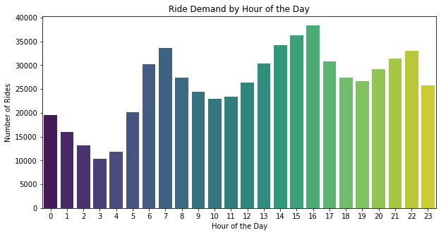

```python
# Plot ride demand by hour
plt.figure(figsize=(10, 5))
sns.countplot(x=df["hour"], palette="viridis")
plt.xlabel("Hour of the Day")
plt.ylabel("Number of Rides")
plt.title("Ride Demand by Hour of the Day")
plt.show()
```

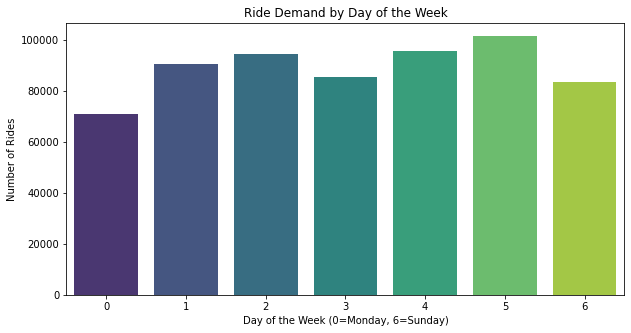

```python
# Plot ride demand by weekday
plt.figure(figsize=(10, 5))
sns.countplot(x=df["weekday"], palette="viridis")
plt.xlabel("Day of the Week (0=Monday, 6=Sunday)")
plt.ylabel("Number of Rides")
plt.title("Ride Demand by Day of the Week")
plt.show()
```

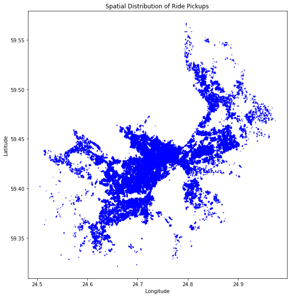

```python
# Create a GeoDataFrame for pickup locations
geometry_start = [Point(xy) for xy in zip(df["start_lng"], df["start_lat"])]
geo_df_start = gpd.GeoDataFrame(df, geometry=geometry_start, crs="EPSG:4326")

# Plot the spatial distribution of ride pickups (sampled)
fig, ax = plt.subplots(figsize=(10, 10))
geo_df_start.plot(ax=ax, markersize=1, alpha=0.5, color="blue")
ax.set_title("Spatial Distribution of Ride Pickups")
plt.xlabel("Longitude")
plt.ylabel("Latitude")
plt.show()
```

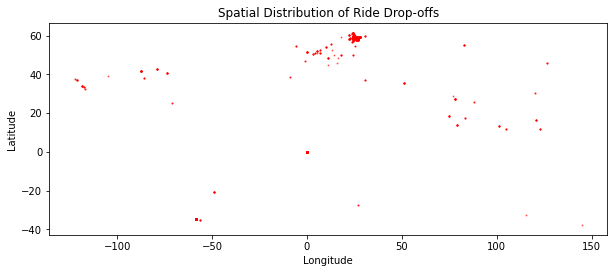

```python
# Create a GeoDataFrame for drop-off locations
geometry_end = [Point(xy) for xy in zip(df["end_lng"], df["end_lat"])]
geo_df_end = gpd.GeoDataFrame(df, geometry=geometry_end, crs="EPSG:4326")

# Plot the spatial distribution of ride drop-offs (sampled)
fig, ax = plt.subplots(figsize=(10, 10))
geo_df_end.plot(ax=ax, markersize=1, alpha=0.5, color="red")
ax.set_title("Spatial Distribution of Ride Drop-offs")
plt.xlabel("Longitude")
plt.ylabel("Latitude")
plt.show()
```

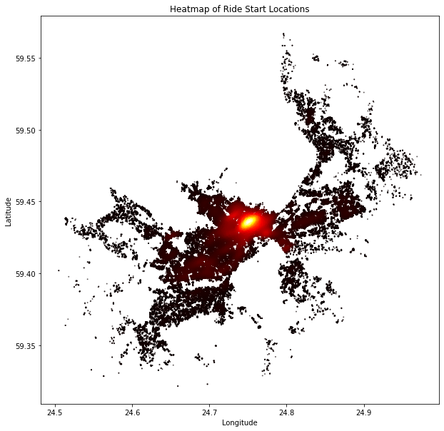

```python
# Heatmap of ride start locations
x = df["start_lng"].values
y = df["start_lat"].values

# Compute point density
xy = np.vstack([x, y])
z = gaussian_kde(xy)(xy)

fig, ax = plt.subplots(figsize=(10, 10))
ax.scatter(x, y, c=z, s=1, cmap='hot', alpha=0.5)
ax.set_title("Heatmap of Ride Start Locations")
plt.xlabel("Longitude")
plt.ylabel("Latitude")
plt.show()
```

```python
c = df.groupby(['year', 'month', 'grid_box_id2'])['ride_value'].sum().reset_index()
```

```python
c["% contribution"] = 100 * c['ride_value']/df['ride_value'].sum()
```

```python
c
```

|  | year | month | grid_box_id2 | ride_value | % contribution |
| --- | --- | --- | --- | --- | --- |
| 0 | 2022 | 3 | 0 | 39772.59 | 2.82 |
| 1 | 2022 | 3 | 1 | 93542.01 | 6.62 |
| 2 | 2022 | 3 | 2 | 7083.23 | 0.50 |
| 3 | 2022 | 3 | 3 | 79713.81 | 5.64 |
| 4 | 2022 | 3 | 4 | 920267.74 | 65.15 |
| 5 | 2022 | 3 | 5 | 207232.15 | 14.67 |
| 6 | 2022 | 3 | 6 | 846.68 | 0.06 |
| 7 | 2022 | 3 | 7 | 890.35 | 0.06 |
| 8 | 2022 | 3 | 8 | 62604.07 | 4.43 |
| 9 | 2022 | 3 | 9 | 478.44 | 0.03 |
| 10 | 2022 | 3 | 10 | 82.73 | 0.01 |
| 11 | 2022 | 3 | 11 | 18.81 | 0.00 |

NOTE: Some of the analysis has been done in excel as data is not big.

# 3. Demand Forecast

### Steps:

1. Generate Demand Forecast across 10 grid big box [Remove the grid boxes has less than 1% ride_value]
2. Distribution of demand forecast over 100 small grid box on the basis of their last week contribution
3. Calculation of accuracy of forecast over small grid box
4. Comparision on accuracy and Conclusion.

```python
### Remove low contributing ride value's grid boxes
monthly_ride_value = df.groupby(['year', 'month', 'grid_box_id2'])['ride_value'].sum().reset_index()
monthly_totals = monthly_ride_value.groupby(['year', 'month'])['ride_value'].sum().reset_index()
monthly_ride_value = monthly_ride_value.merge(monthly_totals, on=['year', 'month'], suffixes=("", "_total"))
monthly_ride_value['percentage'] = (monthly_ride_value['ride_value'] / monthly_ride_value['ride_value_total']) * 100
low_contributing_ids = monthly_ride_value[monthly_ride_value['percentage'] < 1]['grid_box_id2'].unique()
df_filtered = df[~df['grid_box_id2'].isin(low_contributing_ids)].copy()
df_filtered.fillna(0, inplace=True)
df_filtered['date'] = pd.to_datetime(df_filtered[['year', 'month', 'day']])
```

```python
# Aggregate Data for Forecasting (Daily level)
df_agg = df_filtered.groupby(['date', 'grid_box_id2'])['ride_value'].sum().reset_index()
```

```python
def forecast_last_week(df):
    forecasts = []
    unique_grid_boxes = df['grid_box_id2'].unique()

    for grid_id in unique_grid_boxes:
        df_grid = df[df['grid_box_id2'] == grid_id].set_index('date').resample('D').sum()

        # Ensure sufficient data for forecasting
        if len(df_grid) < 14:
            continue

        # Exponential Smoothing
        model_es = ExponentialSmoothing(df_grid['ride_value'], seasonal='add', seasonal_periods=7)
        fit_es = model_es.fit()
        forecast_es = fit_es.forecast(7)  # Predict last 7 days

        # ARIMA Model
        model_arima = ARIMA(df_grid['ride_value'], order=(2,1,2))
        fit_arima = model_arima.fit()
        forecast_arima = fit_arima.forecast(7)  # Predict last 7 days

        # Store forecast results
        forecast_df = pd.DataFrame({
            'date': df_grid.index[-7:],  # Last week dates
            'grid_box_id2': grid_id,
            'forecast_es': forecast_es.values,
            'forecast_arima': forecast_arima.values,
        })
        forecasts.append(forecast_df)

    return pd.concat(forecasts, ignore_index=True)
```

```python
# Generate forecasts for the next week
forecast_df = forecast_last_week(df_agg)
```

```python
# distribute forecasted ride_value from grid_box_id2 to grid_box_id
last_week_data = df_filtered[df_filtered['date'] >= (df_filtered['date'].max() - pd.Timedelta(days=7))]
grid_distribution = last_week_data.groupby(['grid_box_id2', 'grid_box_id'])['ride_value'].sum().reset_index()
grid_distribution['contribution'] = grid_distribution.groupby('grid_box_id2')['ride_value'].transform(lambda x: x / x.sum())
forecast_expanded = forecast_df.merge(grid_distribution[['grid_box_id2', 'grid_box_id', 'contribution']], on='grid_box_id2', how='left')
```

```python
# Merge Forecasts with Actual Values
actual_values = last_week_data.groupby(['date', 'grid_box_id2'])['ride_value'].sum().reset_index()
comparison_df = actual_values.merge(forecast_df, on=['date', 'grid_box_id2'], how='inner')
```

```python
# Calculate Forecast Accuracy
mae_es = mean_absolute_error(comparison_df['ride_value'], comparison_df['forecast_es'])
mse_es = mean_squared_error(comparison_df['ride_value'], comparison_df['forecast_es'])
```

```python
mae_arima = mean_absolute_error(comparison_df['ride_value'], comparison_df['forecast_arima'])
mse_arima = mean_squared_error(comparison_df['ride_value'], comparison_df['forecast_arima'])
```

```python
## Results
accuracy_results = pd.DataFrame({
    'Forecasting Method': ['Exponential Smoothing', 'ARIMA'],
    'Mean Absolute Error (MAE)': [mae_es, mae_arima],
    'Mean Squared Error (MSE)': [mse_es, mse_arima]
})
```

```python
accuracy_results
```

|  | Forecasting Method | Mean Absolute Error (MAE) | Mean Squared Error (MSE) |
| --- | --- | --- | --- |
| 0 | Exponential Smoothing | 1824.99 | 8233923.91 |
| 1 | ARIMA | 1773.92 | 5946981.59 |

```python
pd.options.display.float_format = '{:.2f}'.format
```

### *Trying forecasting using XGBoost, expecting a better accuracy.*

## Forecasting using XGBoost

```python
# Select last week's data for forecasting
last_week_start = df_agg['date'].max() - pd.Timedelta(days=6)
last_week_data = df_agg[df_agg['date'] >= last_week_start]
```

```python
# Feature Engineering: Creating Lag Features & Rolling Statistics for XGBoost
def create_features(data):
    """Creates lag and rolling statistics features for time series forecasting."""
    for lag in [1, 7, 14]:
        data[f'lag_{lag}'] = data.groupby('grid_box_id2')['ride_value'].shift(lag)

    # Rolling Mean & Standard Deviation
    data['rolling_mean_7'] = data.groupby('grid_box_id2')['ride_value'].transform(lambda x: x.rolling(7).mean())
    data['rolling_std_7'] = data.groupby('grid_box_id2')['ride_value'].transform(lambda x: x.rolling(7).std())

    return data
```

```python
df_agg = create_features(df_agg)
df_agg.dropna(inplace=True)  # Drop rows with NaN values from lag features
```

```python
# Split Data: Train Before Last Week, Test = Last Week
train = df_agg[df_agg['date'] < last_week_start]
test = df_agg[df_agg['date'] >= last_week_start]

X_train = train.drop(columns=['date', 'ride_value'])
y_train = train['ride_value']
X_test = test.drop(columns=['date', 'ride_value'])
y_test = test['ride_value']
```

```python
# Hyperparameter Tuning for XGBoost using GridSearchCV
param_grid = {
    'n_estimators': [100, 200],
    'learning_rate': [0.01, 0.1, 0.2],
    'max_depth': [3, 5, 7],
}

xgb_model = xgb.XGBRegressor(objective='reg:squarederror')
grid_search = GridSearchCV(xgb_model, param_grid, scoring='neg_mean_absolute_error', cv=3)
grid_search.fit(X_train, y_train)
```

```
GridSearchCV(cv=3,
             estimator=XGBRegressor(base_score=None, booster=None,
                                    callbacks=None, colsample_bylevel=None,
                                    colsample_bynode=None,
                                    colsample_bytree=None,
                                    early_stopping_rounds=None,
                                    enable_categorical=False, eval_metric=None,
                                    feature_types=None, gamma=None, gpu_id=None,
                                    grow_policy=None, importance_type=None,
                                    interaction_constraints=None,
                                    learning_rate=None, m...
                                    max_cat_threshold=None,
                                    max_cat_to_onehot=None, max_delta_step=None,
                                    max_depth=None, max_leaves=None,
                                    min_child_weight=None, missing=nan,
                                    monotone_constraints=None, n_estimators=100,
                                    n_jobs=None, num_parallel_tree=None,
                                    predictor=None, random_state=None, ...),
             param_grid={'learning_rate': [0.01, 0.1, 0.2],
                         'max_depth': [3, 5, 7], 'n_estimators': [100, 200]},
             scoring='neg_mean_absolute_error')
```

```python
# Train Best XGBoost Model
best_xgb_model = grid_search.best_estimator_
best_xgb_model.fit(X_train, y_train)
```

```
XGBRegressor(base_score=None, booster=None, callbacks=None,
             colsample_bylevel=None, colsample_bynode=None,
             colsample_bytree=None, early_stopping_rounds=None,
             enable_categorical=False, eval_metric=None, feature_types=None,
             gamma=None, gpu_id=None, grow_policy=None, importance_type=None,
             interaction_constraints=None, learning_rate=0.2, max_bin=None,
             max_cat_threshold=None, max_cat_to_onehot=None,
             max_delta_step=None, max_depth=3, max_leaves=None,
             min_child_weight=None, missing=nan, monotone_constraints=None,
             n_estimators=100, n_jobs=None, num_parallel_tree=None,
             predictor=None, random_state=None, ...)
```

```python
# Predict Last 7 Days with XGBoost
y_pred_xgb = best_xgb_model.predict(X_test)
```

```python
# Predict Last 7 Days with XGBoost
y_pred_xgb = best_xgb_model.predict(X_test)
```

```python
def forecast_last_week(df):
    forecasts = []
    unique_grid_boxes = df['grid_box_id2'].unique()

    for grid_id in unique_grid_boxes:
        df_grid = df[df['grid_box_id2'] == grid_id].set_index('date').resample('D').sum()

        # Ensure sufficient data for forecasting
        if len(df_grid) < 14:
            continue

        # Exponential Smoothing
        model_es = ExponentialSmoothing(df_grid['ride_value'], seasonal='add', seasonal_periods=7)
        fit_es = model_es.fit()
        forecast_es = fit_es.forecast(7)

        # ARIMA Model
        model_arima = ARIMA(df_grid['ride_value'], order=(2,1,2))
        fit_arima = model_arima.fit()
        forecast_arima = fit_arima.forecast(7)

        # Store forecast results
        forecast_df = pd.DataFrame({
            'date': df_grid.index[-7:],
            'grid_box_id2': grid_id,
            'forecast_es': forecast_es.values,
            'forecast_arima': forecast_arima.values,
        })
        forecasts.append(forecast_df)

    return pd.concat(forecasts, ignore_index=True)
```

```python
forecast_df = forecast_last_week(df_agg)
```

```python
# Merge Forecasts with Actual Values
actual_values = last_week_data.groupby(['date', 'grid_box_id2'])['ride_value'].sum().reset_index()
comparison_df = actual_values.merge(forecast_df, on=['date', 'grid_box_id2'], how='inner')

# Compute Forecast Accuracy
mae_es = mean_absolute_error(comparison_df['ride_value'], comparison_df['forecast_es'])
mse_es = mean_squared_error(comparison_df['ride_value'], comparison_df['forecast_es'])

mae_arima = mean_absolute_error(comparison_df['ride_value'], comparison_df['forecast_arima'])
mse_arima = mean_squared_error(comparison_df['ride_value'], comparison_df['forecast_arima'])

mae_xgb = mean_absolute_error(y_test, y_pred_xgb)
mse_xgb = mean_squared_error(y_test, y_pred_xgb)
```

```python
# Save Results
accuracy_results = pd.DataFrame({
    'Forecasting Method': ['Exponential Smoothing', 'ARIMA', 'XGBoost'],
    'Mean Absolute Error (MAE)': [mae_es, mae_arima, mae_xgb],
    'Mean Squared Error (MSE)': [mse_es, mse_arima, mse_xgb]
})
```

```python
accuracy_results
```

|  | Forecasting Method | Mean Absolute Error (MAE) | Mean Squared Error (MSE) |
| --- | --- | --- | --- |
| 0 | Exponential Smoothing | 1162.91 | 8496496.14 |
| 1 | ARIMA | 2130.09 | 8579873.92 |
| 2 | XGBoost | 2501.87 | 15875644.17 |

# Conclusion of the Case study:

1. Results:  
   i) On the basis of accuracy results: The Exponential Smoothing (ETS) Algorithm has the better results over ARIMA and XGBoost.  
   Simple algorithms perfoms better in case of less data.  
   ii) XGBoost does't perform well due to less historical data (only 3 weeks data are available) and features, it may perform better if more historical data available (atleast 6 months to a year).  
   iii) The accuracy has been calculated on daily basis and it is a direct calculation instead of weighted (on the basis of contribution). The weighted accuracy can look a little better at hourly basis.
2. Deployement:  
   i) For the deployement, we need to run the model daily with data of previous day extended until historically avaiable.  
   ii) The final demand forecast needs to be distributed hourly for every location (Loc_S) so that the driver knows where and when they need to move for more ride.  
   iii) In the case study 'ride_value' has been taken instead of "ride_count" asuming that high value with low count is better than low value with high count. It means the case study is directly focusing on the monetary aspect. If the count of rides accounts to more profit to company then ride_value should be replaced by count of rides.

## 3. Scope and Challenges:

### *This is simple case study with limited data, but the actual real-life scenario would be different. Using more complex algorithms and data we can improve the profitability with optimization, following are some recommendations:*

```
1. More historical data needed. For eg. ride end time is also an important feature.
2. The availability of weather data significantly impact the demand of riders.
3. Most taxi companies uses surge pricing, surge pricing data trends can be analyzed to anticipate high-demand areas.
4. Important events (like sports), concert and local festivals information can be useful for analysing high demand area and time
5. Since the data is very flat, if we have Customer and Driver IDs then we can recommend the rides to the driver more efficiently.
6. Use of geographical tool like ArcGIS create more impact in solution, as these tools have excelent GIS capabilities. e.g. POINT Geometry and geodataframe with CRS 4326 is better than making a square grid box.
7. Some more important features like details of the ride (premium/economy, distance travel, riders/driver details with rating, area information like airport etc.) impacts the recomendation.
8. More features leads to multivariate analysis which performs better than time-series.
9. Route optimisation (like TSP problem) is a whole different thing and complex but incorporation of route optimisation and recomendation impcats the demand and value.
```